# Assignment3

# Problem 2: Predicting Student Performance

## Data Exploration

```r
students <- read.csv("student-mat.csv", sep=";", header=T, stringsAsFactors=T)
cat <- c(n, n, c, n, c, n, o, o, n, n, n, n, o, o, o, n, n, n, n, n, n, n, n, o, o, o, o, o, o, c, c, c)
```

Similar to the previous problem, a lot of the variables in this dataset are numeric. but they represent an ordinal value, such as `Medu` (mother’s education) and `Fedu` (father’s education), `traveltime`, `studytime`, etc. Even these specific variables are numeric in what they represent, but the fact that they’re floored and quantized transforms their continuous nature into an ordinal categorical one.

### Data Summary

```r
summary(students)
```

```
##  school   sex          age       address famsize   Pstatus      Medu
##  GP:349   F:208   Min.   :15.0   R: 88   GT3:281   A: 41   Min.   :0.000
##  MS: 46   M:187   1st Qu.:16.0   U:307   LE3:114   T:354   1st Qu.:2.000
##                   Median :17.0                             Median :3.000
##                   Mean   :16.7                             Mean   :2.749
##                   3rd Qu.:18.0                             3rd Qu.:4.000
##                   Max.   :22.0                             Max.   :4.000
##       Fedu             Mjob           Fjob            reason      guardian
##  Min.   :0.000   at_home : 59   at_home : 20   course    :145   father: 90
##  1st Qu.:2.000   health  : 34   health  : 18   home      :109   mother:273
##  Median :2.000   other   :141   other   :217   other     : 36   other : 32
##  Mean   :2.522   services:103   services:111   reputation:105
##  3rd Qu.:3.000   teacher : 58   teacher : 29
##  Max.   :4.000
##    traveltime      studytime        failures      schoolsup famsup     paid
##  Min.   :1.000   Min.   :1.000   Min.   :0.0000   no :344   no :153   no :214
##  1st Qu.:1.000   1st Qu.:1.000   1st Qu.:0.0000   yes: 51   yes:242   yes:181
##  Median :1.000   Median :2.000   Median :0.0000
##  Mean   :1.448   Mean   :2.035   Mean   :0.3342
##  3rd Qu.:2.000   3rd Qu.:2.000   3rd Qu.:0.0000
##  Max.   :4.000   Max.   :4.000   Max.   :3.0000
##  activities nursery   higher    internet  romantic      famrel
##  no :194    no : 81   no : 20   no : 66   no :263   Min.   :1.000
##  yes:201    yes:314   yes:375   yes:329   yes:132   1st Qu.:4.000
##                                                     Median :4.000
##                                                     Mean   :3.944
##                                                     3rd Qu.:5.000
##                                                     Max.   :5.000
##     freetime         goout            Dalc            Walc
##  Min.   :1.000   Min.   :1.000   Min.   :1.000   Min.   :1.000
##  1st Qu.:3.000   1st Qu.:2.000   1st Qu.:1.000   1st Qu.:1.000
##  Median :3.000   Median :3.000   Median :1.000   Median :2.000
##  Mean   :3.235   Mean   :3.109   Mean   :1.481   Mean   :2.291
##  3rd Qu.:4.000   3rd Qu.:4.000   3rd Qu.:2.000   3rd Qu.:3.000
##  Max.   :5.000   Max.   :5.000   Max.   :5.000   Max.   :5.000
##      health         absences            G1              G2
##  Min.   :1.000   Min.   : 0.000   Min.   : 3.00   Min.   : 0.00
##  1st Qu.:3.000   1st Qu.: 0.000   1st Qu.: 8.00   1st Qu.: 9.00
##  Median :4.000   Median : 4.000   Median :11.00   Median :11.00
##  Mean   :3.554   Mean   : 5.709   Mean   :10.91   Mean   :10.71
##  3rd Qu.:5.000   3rd Qu.: 8.000   3rd Qu.:13.00   3rd Qu.:13.00
##  Max.   :5.000   Max.   :75.000   Max.   :19.00   Max.   :19.00
##        G3
##  Min.   : 0.00
##  1st Qu.: 8.00
##  Median :11.00
##  Mean   :10.42
##  3rd Qu.:14.00
##  Max.   :20.00
```

```r
str(students)
```

```
## 'data.frame':    395 obs. of  33 variables:
##  $ school    : Factor w/ 2 levels "GP","MS": 1 1 1 1 1 1 1 1 1 1 ...
##  $ sex       : Factor w/ 2 levels "F","M": 1 1 1 1 1 2 2 1 2 2 ...
##  $ age       : int  18 17 15 15 16 16 16 17 15 15 ...
##  $ address   : Factor w/ 2 levels "R","U": 2 2 2 2 2 2 2 2 2 2 ...
##  $ famsize   : Factor w/ 2 levels "GT3","LE3": 1 1 2 1 1 2 2 1 2 1 ...
##  $ Pstatus   : Factor w/ 2 levels "A","T": 1 2 2 2 2 2 2 1 1 2 ...
##  $ Medu      : int  4 1 1 4 3 4 2 4 3 3 ...
##  $ Fedu      : int  4 1 1 2 3 3 2 4 2 4 ...
##  $ Mjob      : Factor w/ 5 levels "at_home","health",..: 1 1 1 2 3 4 3 3 4 3 ...
##  $ Fjob      : Factor w/ 5 levels "at_home","health",..: 5 3 3 4 3 3 3 5 3 3 ...
##  $ reason    : Factor w/ 4 levels "course","home",..: 1 1 3 2 2 4 2 2 2 2 ...
##  $ guardian  : Factor w/ 3 levels "father","mother",..: 2 1 2 2 1 2 2 2 2 2 ...
##  $ traveltime: int  2 1 1 1 1 1 1 2 1 1 ...
##  $ studytime : int  2 2 2 3 2 2 2 2 2 2 ...
```

[output cut: 19 more lines]

### Missing Values

Looking at the data summary, there doesn’t seem to be any missing values for any column. Each nominal value has the correct number of factors explained by the student.txt file, and all the numeric values fall into the correct range.

### Statistic Tests

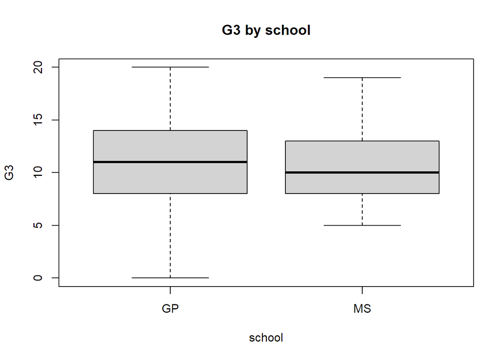

```
## [1] "===== T-Test for school ====="
##
##  Welch Two Sample t-test
##
## data:  G3 by otherC
## t = 0.95555, df = 60.054, p-value = 0.3431
## alternative hypothesis: true difference in means between group GP and group MS is not equal to 0
## 95 percent confidence interval:
##  -0.7020663  1.9863568
## sample estimates:
## mean in group GP mean in group MS
##        10.489971         9.847826
##
## [1] "===== ANOVA Test for school ====="
##
##  One-way analysis of means (not assuming equal variances)
##
## data:  G3 and otherC
## F = 0.91307, num df = 1.000, denom df = 60.054, p-value = 0.3431
```

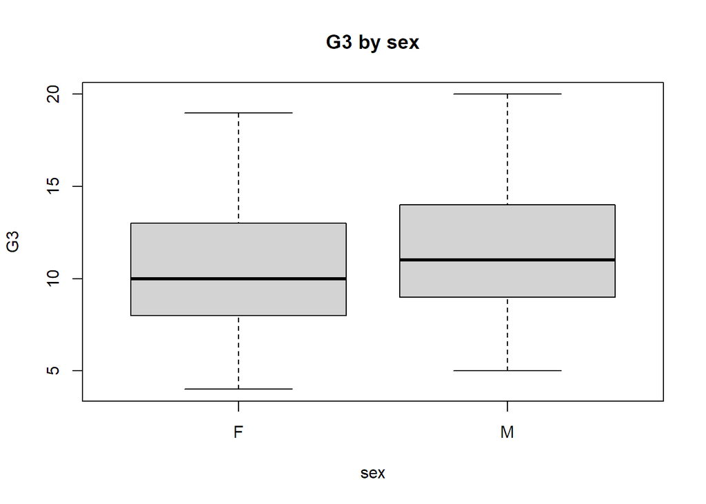

```
## [1] "===== T-Test for sex ====="
##
##  Welch Two Sample t-test
##
## data:  G3 by otherC
## t = -2.0651, df = 390.57, p-value = 0.03958
## alternative hypothesis: true difference in means between group F and group M is not equal to 0
## 95 percent confidence interval:
##  -1.85073226 -0.04545244
## sample estimates:
## mean in group F mean in group M
##        9.966346       10.914439
##
## [1] "===== ANOVA Test for sex ====="
##
##  One-way analysis of means (not assuming equal variances)
##
## data:  G3 and otherC
## F = 4.2645, num df = 1.00, denom df = 390.57, p-value = 0.03958
```

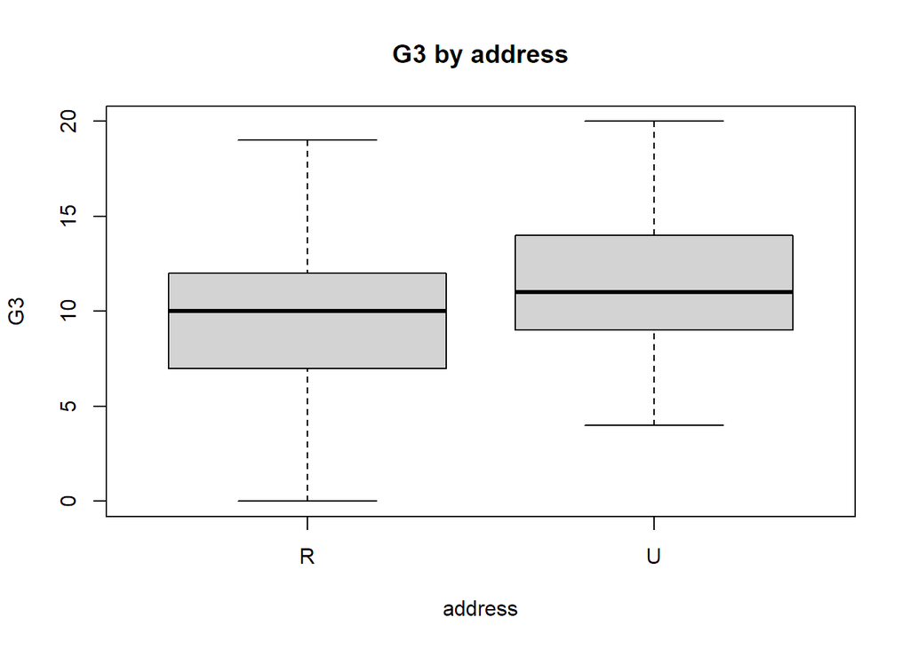

```
## [1] "===== T-Test for address ====="
##
##  Welch Two Sample t-test
##
## data:  G3 by otherC
## t = -2.1101, df = 140.91, p-value = 0.03661
## alternative hypothesis: true difference in means between group R and group U is not equal to 0
## 95 percent confidence interval:
##  -2.25240320 -0.07340373
## sample estimates:
## mean in group R mean in group U
##        9.511364       10.674267
##
## [1] "===== ANOVA Test for address ====="
##
##  One-way analysis of means (not assuming equal variances)
##
## data:  G3 and otherC
## F = 4.4527, num df = 1.00, denom df = 140.91, p-value = 0.03661
```

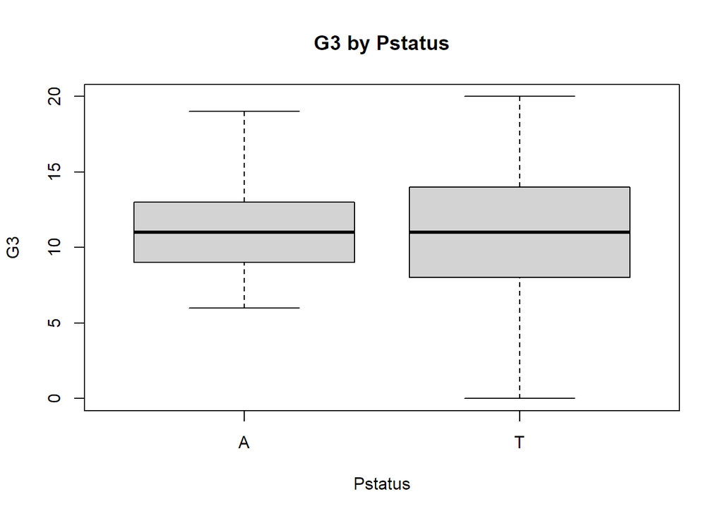

```
## [1] "===== T-Test for Pstatus ====="
##
##  Welch Two Sample t-test
##
## data:  G3 by otherC
## t = 1.2197, df = 51.312, p-value = 0.2282
## alternative hypothesis: true difference in means between group A and group T is not equal to 0
## 95 percent confidence interval:
##  -0.5619775  2.3025039
## sample estimates:
## mean in group A mean in group T
##        11.19512        10.32486
##
## [1] "===== ANOVA Test for Pstatus ====="
##
##  One-way analysis of means (not assuming equal variances)
##
## data:  G3 and otherC
## F = 1.4876, num df = 1.000, denom df = 51.312, p-value = 0.2282
```

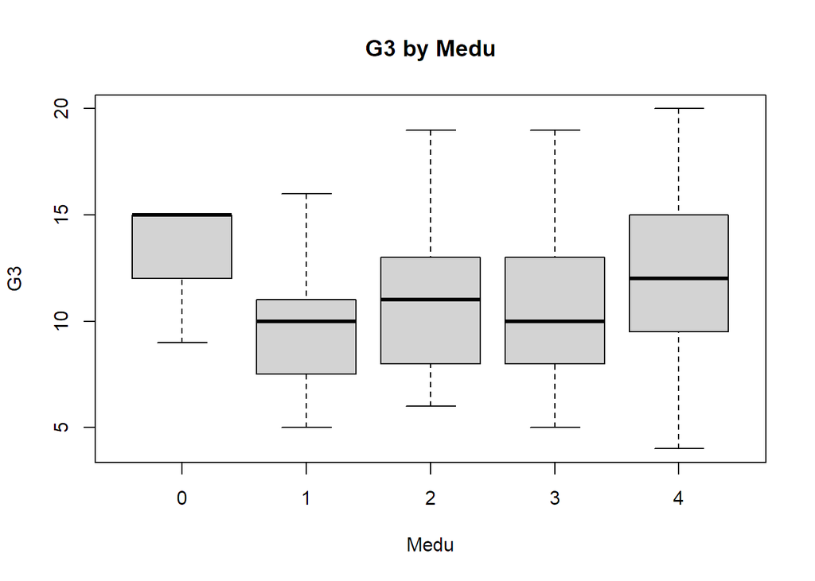

```
## [1] "===== ANOVA Test for Medu ====="
##
##  One-way analysis of means (not assuming equal variances)
##
## data:  G3 and otherC
## F = 5.8353, num df = 4.000, denom df = 15.543, p-value = 0.004553
```

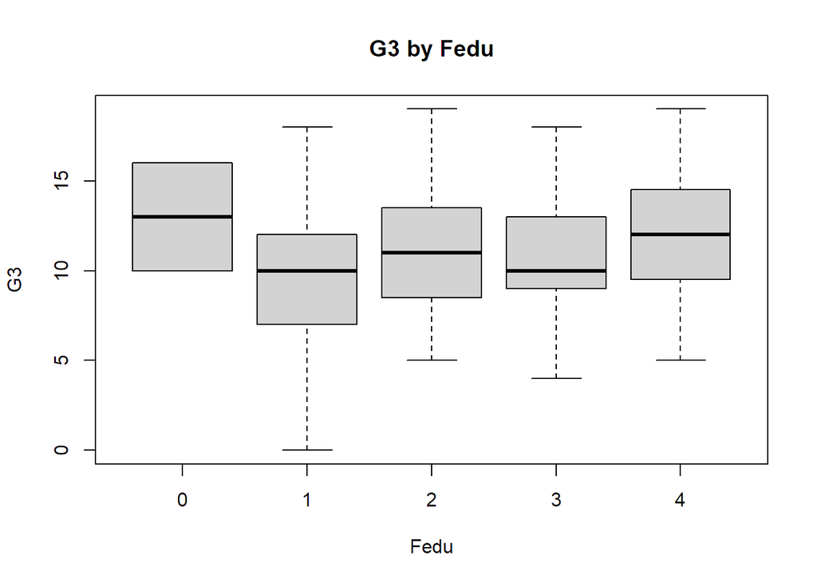

```
## [1] "===== ANOVA Test for Fedu ====="
##
##  One-way analysis of means (not assuming equal variances)
##
## data:  G3 and otherC
## F = 2.2751, num df = 4.000, denom df = 7.902, p-value = 0.1509
```

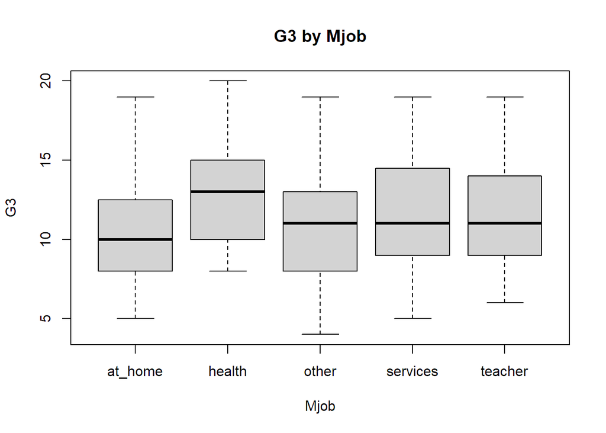

```
## [1] "===== ANOVA Test for Mjob ====="
##
##  One-way analysis of means (not assuming equal variances)
##
## data:  G3 and otherC
## F = 3.7885, num df = 4.0, denom df = 136.4, p-value = 0.005927
```

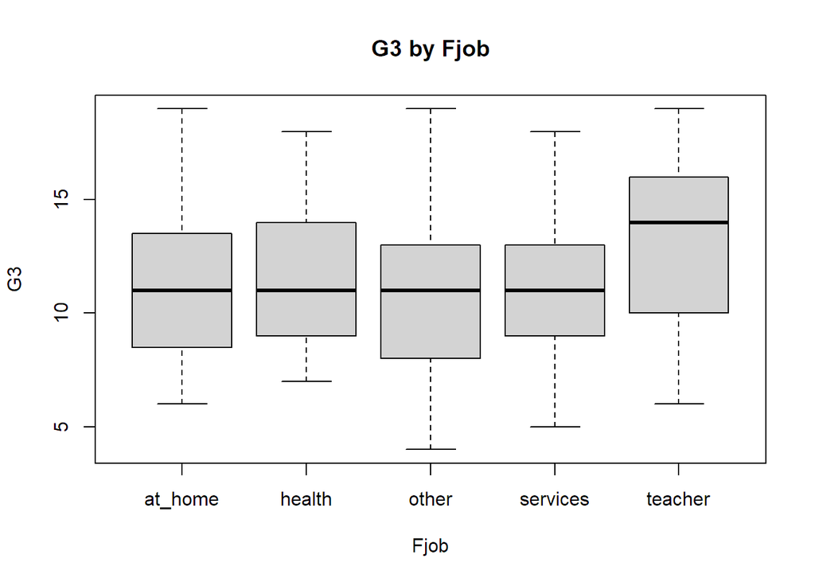

```
## [1] "===== ANOVA Test for Fjob ====="
##
##  One-way analysis of means (not assuming equal variances)
##
## data:  G3 and otherC
## F = 1.3092, num df = 4.000, denom df = 58.911, p-value = 0.2771
```

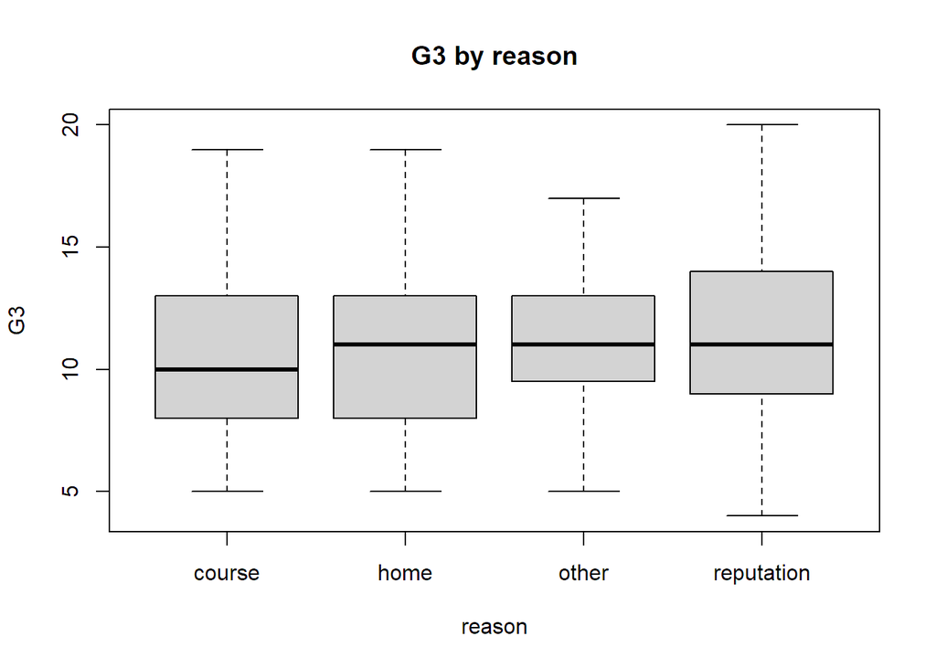

```
## [1] "===== ANOVA Test for reason ====="
##
##  One-way analysis of means (not assuming equal variances)
##
## data:  G3 and otherC
## F = 2.1899, num df = 3.00, denom df = 144.09, p-value = 0.0918
```

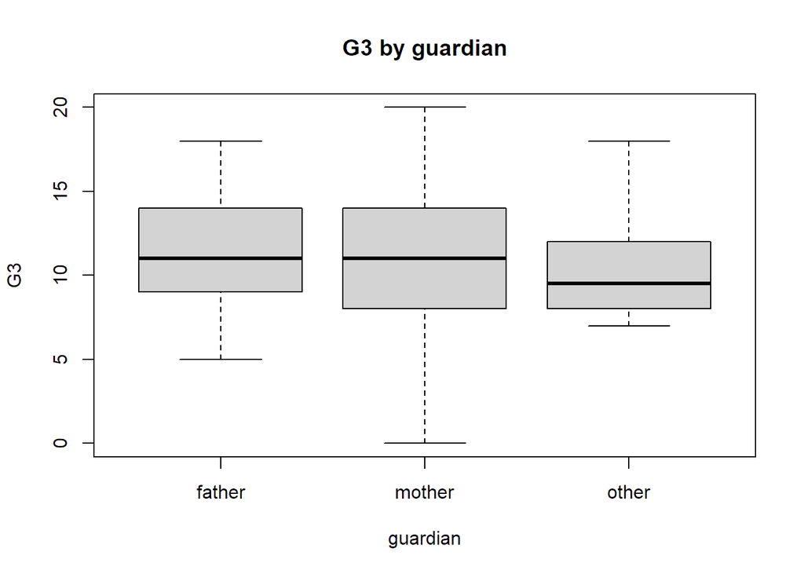

```
## [1] "===== ANOVA Test for guardian ====="
##
##  One-way analysis of means (not assuming equal variances)
##
## data:  G3 and otherC
## F = 1.5167, num df = 2.000, denom df = 77.625, p-value = 0.2259
```

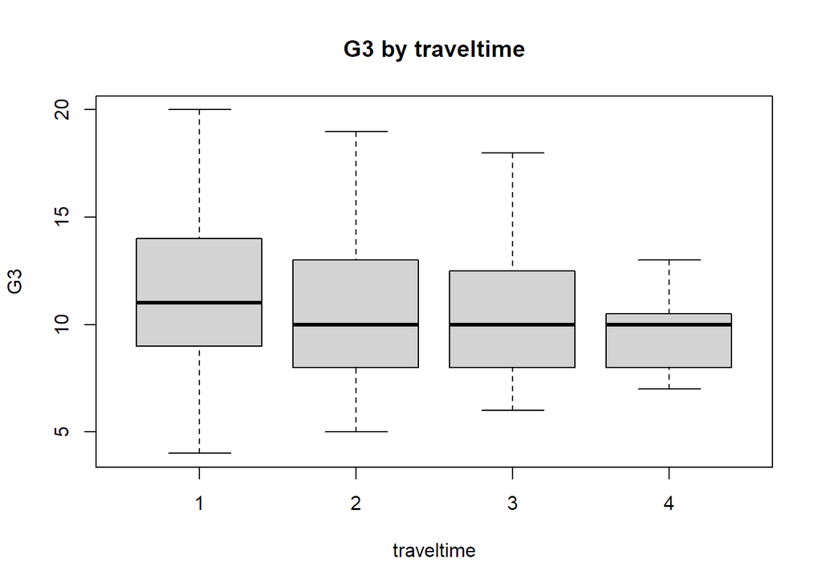

```
## [1] "===== ANOVA Test for traveltime ====="
##
##  One-way analysis of means (not assuming equal variances)
##
## data:  G3 and otherC
## F = 1.7908, num df = 3.000, denom df = 27.477, p-value = 0.1723
```

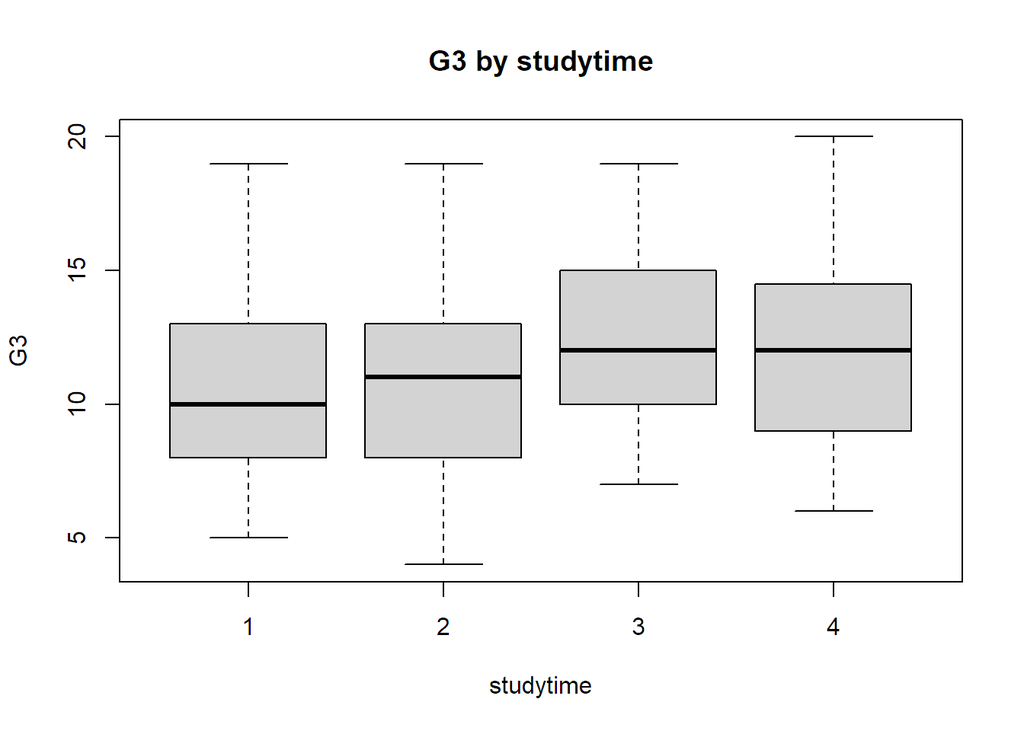

```
## [1] "===== ANOVA Test for studytime ====="
##
##  One-way analysis of means (not assuming equal variances)
##
## data:  G3 and otherC
## F = 1.5921, num df = 3.000, denom df = 95.019, p-value = 0.1964
```

[15 more figures not shown]

```
## [1] "===== ANOVA Test for health ====="
##
##  One-way analysis of means (not assuming equal variances)
##
## data:  G3 and otherC
## F = 1.5877, num df = 4.00, denom df = 143.41, p-value = 0.1807
```

```r
# setup
library(gmodels)
library(vcd)

# create a data frame to store the values calculated from the Spearman rank correlations
spearman_vals <- data.frame(0)

# for each column in the bank dataset, determine the classification of the data by referring to the cat vector and run the appropriate test based on that value
c <- 1
G3 <- students[,"G3"]
while(c <= length(cat)){
  otherC <- students[,c]
  otherN <- colnames(students[c])

  if(cat[c] == n || cat[c] == o){
    # categorical value, use Side-By-Side Boxplot
    boxplot(G3~otherC, main = paste("G3 by", otherN), ylab = "G3", xlab = otherN, outline=F)
    if(nlevels(students[,c]) == 2){
      print(paste("===== T-Test for", otherN, "====="))
      print(t.test(G3~otherC, alternative="two.sided"))
    }
    anova <- oneway.test(G3~otherC)
    print(paste("===== ANOVA Test for", otherN, "====="))
    print(anova)
  }else if(cat[c] == o){
    a <- aov(G3~otherC)
    print(paste("===== ANOVA Test for", otherN, "====="))
    print(a)
  }else{
     spearman_vals[otherN] <- cor(y=G3, x=as.numeric(otherC), method="spearman", use="pairwise.complete.obs")
  }
  c <- c + 1
}
```

```r
# remove placeholder value from vector
spearman_vals[1] <- NULL

print(spearman_vals)
```

```
##          age    famsize   absences        G1        G2
## 1 -0.1734375 0.06627919 0.01773067 0.8780013 0.9571253
```

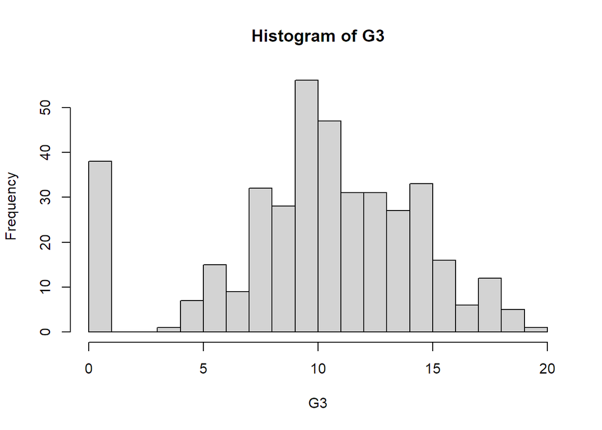

```r
hist(G3, xlab = "G3", main = "Histogram of G3", breaks = 20)
```

### Analysis

According to the statistic tests’ p-values, the following variables have statistical significance (at $\alpha$ = 0.01) in describing G3 or have at least a moderate correlation according to the Spearman Rank tests:

- Medu
- Mjob
- Failures
- higher
- G1
- G2

Looking at the boxplots, other possible good indicators (despite the p-values) might be:

- Fedu
- Fjob
- schoolsup
- internet
- freetime

I tried to perform One-Way ANOVA tests on the ordinal data, but I got errors from R saying there were not enough observations, which seems to mean that one or more factors in each of the independent variables had insufficient entries in the data, which does make sense when you consider the side of this dataset is relatively small compared to those we’ve worked with prior.

The histogram shows a relatively normal distribution, though slightly positively skewed and with a large set of outliers at G3 = 0. These could theoretically represent missing data, such as students who did not take the test at all, but the value 0 is within the range of the scores for the G3 variable, so I am inclined to leave it as to not affect results or incorrectly manipulate data.

## Data Manipulation

### Remove Unassociated Variables

```r
students["school"] <- NULL
students["sex"] <- NULL
students["address"] <- NULL
students["Pstatus"] <- NULL
students["reason"] <- NULL
students["guardian"] <- NULL
students["traveltime"] <- NULL
students["studytime"] <- NULL
students["famsup"] <- NULL
students["paid"] <- NULL
students["activities"] <- NULL
students["nursery"] <- NULL
students["romantic"] <- NULL
students["famrel"] <- NULL
students["goout"] <- NULL
students["Dalc"] <- NULL
students["Walc"] <- NULL
students["health"] <- NULL
students["age"] <- NULL
students["famsize"] <- NULL
students["absences"] <- NULL
```

### Convert Factors to numeric

```r
students[,"Mjob"] <- as.numeric(students[,"Mjob"])
students[,"Fjob"] <- as.numeric(students[,"Fjob"])
students[,"schoolsup"] <- as.numeric(students[,"schoolsup"])
students[,"higher"] <- as.numeric(students[,"higher"])
students[,"internet"] <- as.numeric(students[,"internet"])
```

### Split Data

```r
library(caret)

set.seed(123)

indices <- createDataPartition(G3, times=1, p=.8, list=FALSE)
training_data <- students[indices,]
testing_data <- students[-indices,]

training_set <- training_data[,1:ncol(training_data) - 1]
test_set <- testing_data[,1:ncol(testing_data) - 1]
```

## Train a Model using 10 Fold CV using Linear Regression

```r
set.seed(123)
control <- trainControl(method = "cv", number = 10)
model <- train(G3 ~ ., data = training_data, method = "lm", trControl = control)
```

### Model Info

```r
print(model)
```

```
## Linear Regression
##
## 318 samples
##  11 predictor
##
## No pre-processing
## Resampling: Cross-Validated (10 fold)
## Summary of sample sizes: 285, 287, 286, 287, 287, 285, ...
## Resampling results:
##
##   RMSE      Rsquared   MAE
##   1.988747  0.8153425  1.215811
##
## Tuning parameter 'intercept' was held constant at a value of TRUE
```

```r
summary(model)
```

```
##
## Call:
## lm(formula = .outcome ~ ., data = dat)
##
## Residuals:
##     Min      1Q  Median      3Q     Max
## -9.3439 -0.3305  0.3299  0.9251  3.2535
##
## Coefficients:
##             Estimate Std. Error t value Pr(>|t|)
## (Intercept) -2.61089    1.45729  -1.792   0.0742 .
## Medu         0.22165    0.14808   1.497   0.1355
## Fedu        -0.16864    0.13736  -1.228   0.2205
## Mjob        -0.01398    0.10665  -0.131   0.8958
## Fjob        -0.07723    0.13571  -0.569   0.5697
## failures    -0.09942    0.17660  -0.563   0.5739
## schoolsup    0.52972    0.34739   1.525   0.1283
## higher      -0.02341    0.55540  -0.042   0.9664
## internet     0.01040    0.30382   0.034   0.9727
## freetime     0.13064    0.11289   1.157   0.2481
## G1           0.17033    0.06692   2.545   0.0114 *
## G2           0.96220    0.05764  16.694   <2e-16 ***
## ---
## Signif. codes:  0 '***' 0.001 '**' 0.01 '*' 0.05 '.' 0.1 ' ' 1
##
## Residual standard error: 1.999 on 306 degrees of freedom
## Multiple R-squared:  0.8201, Adjusted R-squared:  0.8136
## F-statistic: 126.8 on 11 and 306 DF,  p-value: < 2.2e-16
```

The coefficients with the highest statistical significance were G1 and G2, which makes the sense because G3 could be calculated partly using G1 and G2, but at the very least G1 and G2 are measures of the students performance in the math class, which G3 is also measuring. The next most significant coefficient was from schoolsup, which also makes sense because a student that is seeking out extra help from the school clearly cares about the grade they receive and will want to try to increase it as much as possible; furthermore, that supplemental help could allow the student to understand concepts better and, therefore, perform better on homework and tests.

Coefficients that are statistically different from zero imply that there is a statistical correlation between that variable and the resulting variable (G3).

### Test the Model

```r
prediction <- predict(model, test_set)
print(paste("RMSE:", rmse(testing_data$G3, prediction)))
```

```
## [1] "RMSE: 1.68915025460915"
```

## Train a Model using 10 Fold CV using Step-Wise Linear Regression

```r
library(LEAP)
set.seed(123)
stepwise.model <- train(G3 ~ ., data = training_data, method = "leapBackward", trControl = control, tuneGrid=data.frame(nvmax=2:ncol(training_set)))
```

### Model info

```r
print(stepwise.model)
```

```
## Linear Regression with Backwards Selection
##
## 318 samples
##  11 predictor
##
## No pre-processing
## Resampling: Cross-Validated (10 fold)
## Summary of sample sizes: 285, 287, 286, 287, 287, 285, ...
## Resampling results across tuning parameters:
##
##   nvmax  RMSE      Rsquared   MAE
##    2     1.935542  0.8260584  1.145494
##    3     1.967830  0.8200979  1.178636
##    4     1.976407  0.8182914  1.188231
##    5     1.973104  0.8184570  1.195145
##    6     1.970854  0.8180538  1.203700
##    7     1.977257  0.8169367  1.209423
##    8     1.983842  0.8159411  1.214612
##    9     1.985326  0.8157859  1.215106
##   10     1.989411  0.8152318  1.216497
##   11     1.988747  0.8153425  1.215811
##
## RMSE was used to select the optimal model using the smallest value.
## The final value used for the model was nvmax = 2.
```

```r
summary(stepwise.model)
```

```
## Subset selection object
## 11 Variables  (and intercept)
##           Forced in Forced out
## Medu          FALSE      FALSE
## Fedu          FALSE      FALSE
## Mjob          FALSE      FALSE
## Fjob          FALSE      FALSE
## failures      FALSE      FALSE
## schoolsup     FALSE      FALSE
## higher        FALSE      FALSE
## internet      FALSE      FALSE
## freetime      FALSE      FALSE
## G1            FALSE      FALSE
## G2            FALSE      FALSE
## 1 subsets of each size up to 2
## Selection Algorithm: backward
##          Medu Fedu Mjob Fjob failures schoolsup higher internet freetime G1
## 1  ( 1 ) " "  " "  " "  " "  " "      " "       " "    " "      " "      " "
## 2  ( 1 ) " "  " "  " "  " "  " "      " "       " "    " "      " "      "*"
##          G2
## 1  ( 1 ) "*"
## 2  ( 1 ) "*"
```

The best model (using the variables I selected) only used two variables, those being G1 and G2: based on the results of the other model, no other variable came close to having the same statistical significance.

### Test the Model

```r
stepwise.prediction <- predict(stepwise.model, test_set)
print(paste("RMSE:", rmse(testing_data$G3, stepwise.prediction)))
```

```
## [1] "RMSE: 1.69563243181546"
```

```r
library(rpart)

tree.model <- rpart(G3 ~ ., data = training_data, method = "class")
```

### Model Info

```r
print(tree.model)
```

```
## n= 318
##
## node), split, n, loss, yval, (yprob)
##       * denotes terminal node
##
##  1) root 318 273 10 (0.097 0.022 0.031 0.025 0.082 0.066 0.14 0.12 0.094 0.069 0.063 0.072 0.044 0.013 0.038 0.016 0.0031)
##    2) G2< 10.5 154 116 10 (0.2 0.045 0.065 0.052 0.17 0.14 0.25 0.071 0.013 0 0 0 0 0 0 0 0)
##      4) G2< 7.5 50  29 0 (0.42 0.14 0.18 0.08 0.14 0.04 0 0 0 0 0 0 0 0 0 0 0)
##        8) G2< 4.5 12   0 0 (1 0 0 0 0 0 0 0 0 0 0 0 0 0 0 0 0) *
##        9) G2>=4.5 38  29 0 (0.24 0.18 0.24 0.11 0.18 0.053 0 0 0 0 0 0 0 0 0 0 0)
##         18) failures>=0.5 17  10 0 (0.41 0.24 0 0.059 0.24 0.059 0 0 0 0 0 0 0 0 0 0 0) *
##         19) failures< 0.5 21  12 6 (0.095 0.14 0.43 0.14 0.14 0.048 0 0 0 0 0 0 0 0 0 0 0) *
##      5) G2>=7.5 104  66 10 (0.096 0 0.0096 0.038 0.18 0.18 0.37 0.11 0.019 0 0 0 0 0 0 0 0)
##       10) G2< 9.5 69  50 8 (0.12 0 0.014 0.058 0.28 0.25 0.25 0.043 0 0 0 0 0 0 0 0 0)
##         20) G1< 7.5 14   5 8 (0.14 0 0 0.14 0.64 0 0.071 0 0 0 0 0 0 0 0 0 0) *
##         21) G1>=7.5 55  38 9 (0.11 0 0.018 0.036 0.18 0.31 0.29 0.055 0 0 0 0 0 0 0 0 0)
##           42) Fjob< 3.5 35  22 10 (0.11 0 0.029 0.057 0.23 0.17 0.37 0.029 0 0 0 0 0 0 0 0 0)
##             84) Fedu>=2.5 12   6 8 (0.083 0 0.083 0 0.5 0.25 0.083 0 0 0 0 0 0 0 0 0 0) *
##             85) Fedu< 2.5 23  11 10 (0.13 0 0 0.087 0.087 0.13 0.52 0.043 0 0 0 0 0 0 0 0 0) *
##           43) Fjob>=3.5 20   9 9 (0.1 0 0 0 0.1 0.55 0.15 0.1 0 0 0 0 0 0 0 0 0) *
##       11) G2>=9.5 35  14 10 (0.057 0 0 0 0 0.057 0.6 0.23 0.057 0 0 0 0 0 0 0 0) *
##    3) G2>=10.5 164 136 11 (0 0 0 0 0 0 0.043 0.17 0.17 0.13 0.12 0.14 0.085 0.024 0.073 0.03 0.0061)
##      6) G2< 12.5 60  33 11 (0 0 0 0 0 0 0.12 0.45 0.37 0.067 0 0 0 0 0 0 0)
##       12) G2< 11.5 30  13 11 (0 0 0 0 0 0 0.2 0.57 0.2 0.033 0 0 0 0 0 0 0) *
##       13) G2>=11.5 30  14 12 (0 0 0 0 0 0 0.033 0.33 0.53 0.1 0 0 0 0 0 0 0) *
##      7) G2>=12.5 104  81 15 (0 0 0 0 0 0 0 0.0096 0.058 0.17 0.19 0.22 0.13 0.038 0.12 0.048 0.0096)
##       14) G2< 14.5 50  31 14 (0 0 0 0 0 0 0 0.02 0.12 0.36 0.38 0.12 0 0 0 0 0)
##         28) G2< 13.5 31  15 13 (0 0 0 0 0 0 0 0.032 0.19 0.52 0.26 0 0 0 0 0 0) *
##         29) G2>=13.5 19   8 14 (0 0 0 0 0 0 0 0 0 0.11 0.58 0.32 0 0 0 0 0) *
##       15) G2>=14.5 54  37 15 (0 0 0 0 0 0 0 0 0 0 0.019 0.31 0.26 0.074 0.22 0.093 0.019)
##         30) G2< 16.5 35  18 15 (0 0 0 0 0 0 0 0 0 0 0.029 0.49 0.4 0.057 0.029 0 0)
##           60) G2< 15.5 25  10 15 (0 0 0 0 0 0 0 0 0 0 0.04 0.6 0.32 0.04 0 0 0) *
##           61) G2>=15.5 10   4 16 (0 0 0 0 0 0 0 0 0 0 0 0.2 0.6 0.1 0.1 0 0) *
##         31) G2>=16.5 19   8 18 (0 0 0 0 0 0 0 0 0 0 0 0 0 0.11 0.58 0.26 0.053) *
```

```r
summary(tree.model)
```

```
## Call:
## rpart(formula = G3 ~ ., data = training_data, method = "class")
##   n= 318
##
##            CP nsplit rel error    xerror       xstd
## 1  0.07875458      0 1.0000000 1.0256410 0.02118823
## 2  0.07692308      2 0.8424908 0.9523810 0.02522461
## 3  0.04761905      3 0.7655678 0.8791209 0.02810456
## 4  0.04029304      4 0.7179487 0.8021978 0.03024569
## 5  0.02930403      5 0.6776557 0.7545788 0.03120085
## 6  0.02197802      6 0.6483516 0.7252747 0.03166263
## 7  0.01953602      7 0.6263736 0.7362637 0.03150030
## 8  0.01831502     10 0.5677656 0.7032967 0.03194918
## 9  0.01465201     11 0.5494505 0.6923077 0.03207374
## 10 0.01282051     12 0.5347985 0.6483516 0.03245039
## 11 0.01000000     14 0.5091575 0.6263736 0.03256721
##
## Variable importance
##        G2        G1      Medu  failures      Fedu      Fjob      Mjob schoolsup
##        49        26         5         5         4         3         3         2
##  freetime    higher
##         1         1
##
## Node number 1: 318 observations,    complexity param=0.07875458
##   predicted class=10  expected loss=0.8584906  P(node) =1
##     class counts:    31     7    10     8    26    21    45    39    30    22    20    23    14     4    12     5     1
##    probabilities: 0.097 0.022 0.031 0.025 0.082 0.066 0.142 0.123 0.094 0.069 0.063 0.072 0.044 0.013 0.038 0.016 0.003
##   left son=2 (154 obs) right son=3 (164 obs)
##   Primary splits:
##       G2        < 10.5 to the left,  improve=19.039620, (0 missing)
##       G1        < 11.5 to the left,  improve=15.695880, (0 missing)
##       failures  < 0.5  to the right, improve= 3.924205, (0 missing)
##       Mjob      < 1.5  to the left,  improve= 2.430861, (0 missing)
##       schoolsup < 1.5  to the right, improve= 1.854499, (0 missing)
##   Surrogate splits:
##       G1        < 10.5 to the left,  agree=0.890, adj=0.773, (0 split)
##       failures  < 0.5  to the right, agree=0.626, adj=0.227, (0 split)
##       Medu      < 2.5  to the left,  agree=0.582, adj=0.136, (0 split)
##       schoolsup < 1.5  to the right, agree=0.582, adj=0.136, (0 split)
##       Fedu      < 3.5  to the left,  agree=0.569, adj=0.110, (0 split)
```

[output cut: 270 more lines]

```
##
## Node number 61: 10 observations
##   predicted class=16  expected loss=0.4  P(node) =0.03144654
##     class counts:     0     0     0     0     0     0     0     0     0     0     0     2     6     1     1     0     0
##    probabilities: 0.000 0.000 0.000 0.000 0.000 0.000 0.000 0.000 0.000 0.000 0.000 0.200 0.600 0.100 0.100 0.000 0.000
##
## Node number 84: 12 observations
##   predicted class=8   expected loss=0.5  P(node) =0.03773585
##     class counts:     1     0     1     0     6     3     1     0     0     0     0     0     0     0     0     0     0
##    probabilities: 0.083 0.000 0.083 0.000 0.500 0.250 0.083 0.000 0.000 0.000 0.000 0.000 0.000 0.000 0.000 0.000 0.000
##
## Node number 85: 23 observations
##   predicted class=10  expected loss=0.4782609  P(node) =0.07232704
##     class counts:     3     0     0     2     2     3    12     1     0     0     0     0     0     0     0     0     0
##    probabilities: 0.130 0.000 0.000 0.087 0.087 0.130 0.522 0.043 0.000 0.000 0.000 0.000 0.000 0.000 0.000 0.000 0.000
```

### Test the Model

```r
tree.prediction <- predict(tree.model, test_set)
print(paste("RMSE:", rmse(testing_data$G3, tree.prediction)))
```

```
## [1] "RMSE: 11.1364170992021"
```

## Conclusion

The first two models predicted with roughly the same RMSE–the 10 Fold CV using Linear Regression performed the best with an RMSE of 1.689, followed by the 10 Fold CV using Step-Wise Linear Regression with an RMSE of 1.696, whereas the tree easily performed the worst with an RMSE of 11.136.